# R_cross_sectional_data

```r
# labor market status

# this is one of the most "complicated variables" -> first look at the questionnaire it says that only those with .. get the question on ..

# most general first option is to create a "super status variable" that combines the general labor market status question and the follow up questions

#first let us get an idea about the levels and codes in these variables
table(as_factor(dataset_r_rec$W6_Q11), useNA="always")
```

```
##
##     Unselbststaendig erwerbstaetig (auch Lehrling), Privatwirtschaft
##                                                                  496
## Unselbststaendig erwerbstaetig (auch Lehrling), Oeffentlicher Dienst
##                                                                  218
##                                         Selbststaendig erwerbstaetig
##                                                                   88
##                                                           Arbeitslos
##                                                                  121
##                                                        Pensionist*in
##                                                                  383
##                                    Ausschliesslich haushaltsfuehrend
##                                                                   30
##                              Schueler/in, Student/in, Bildungskarenz
##                                                                  148
##     Sonstiges (Dauerhaft arbeitsunfaehig oder Praesenz-/Zivildiener)
##                                                                   15
##                                                      In Elternkarenz
##                                                                   35
##                                                         Keine Angabe
##                                                                   17
##                                                                 <NA>
##                                                                    0
```

```r
table(as.numeric(dataset_r_rec$W6_Q11), useNA="always")
```

```
##
##    1    2    3    4    5    6    7    8   10   99 <NA>
##  496  218   88  121  383   30  148   15   35   17    0
```

```r
table(as_factor(dataset_r_rec$W6_Q64A1), useNA="always")
```

```
##
## Nicht genannt       Genannt          <NA>
##           555           247           749
```

```r
table(as.numeric(dataset_r_rec$W6_Q64A1), useNA="always")
```

```
##
##    0    1 <NA>
##  555  247  749
```

```r
#when looking at the cross table one easily sees that not everyone got the follow up questions
table(as_factor(dataset_r_rec$W6_Q11),as_factor(dataset_r_rec$W6_Q64A1), useNA="always")
```

```
##
##                                                                        Nicht genannt
##   Unselbststaendig erwerbstaetig (auch Lehrling), Privatwirtschaft               345
##   Unselbststaendig erwerbstaetig (auch Lehrling), Oeffentlicher Dienst           154
##   Selbststaendig erwerbstaetig                                                    56
##   Arbeitslos                                                                       0
##   Pensionist*in                                                                    0
##   Ausschliesslich haushaltsfuehrend                                                0
##   Schueler/in, Student/in, Bildungskarenz                                          0
##   Sonstiges (Dauerhaft arbeitsunfaehig oder Praesenz-/Zivildiener)                 0
##   In Elternkarenz                                                                  0
##   Keine Angabe                                                                     0
##   <NA>                                                                             0
##
##                                                                        Genannt
##   Unselbststaendig erwerbstaetig (auch Lehrling), Privatwirtschaft         151
##   Unselbststaendig erwerbstaetig (auch Lehrling), Oeffentlicher Dienst      64
##   Selbststaendig erwerbstaetig                                              32
##   Arbeitslos                                                                 0
##   Pensionist*in                                                              0
##   Ausschliesslich haushaltsfuehrend                                          0
##   Schueler/in, Student/in, Bildungskarenz                                    0
##   Sonstiges (Dauerhaft arbeitsunfaehig oder Praesenz-/Zivildiener)           0
##   In Elternkarenz                                                            0
##   Keine Angabe                                                               0
##   <NA>                                                                       0
##
##                                                                        <NA>
##   Unselbststaendig erwerbstaetig (auch Lehrling), Privatwirtschaft        0
##   Unselbststaendig erwerbstaetig (auch Lehrling), Oeffentlicher Dienst    0
##   Selbststaendig erwerbstaetig                                            0
##   Arbeitslos                                                            121
##   Pensionist*in                                                         383
##   Ausschliesslich haushaltsfuehrend                                      30
##   Schueler/in, Student/in, Bildungskarenz                               148
##   Sonstiges (Dauerhaft arbeitsunfaehig oder Praesenz-/Zivildiener)       15
##   In Elternkarenz                                                        35
##   Keine Angabe                                                           17
##   <NA>                                                                    0
```

```r
#lets think about the coding and structure we want to have in our new variable current labor market status: lab_sta_cur

# 0 = (Un)selbststaendig erwerbstaetig (=privat+oeff+selbst) + only those not in Home Office (W6_Q64A1) and not in Kurzarbeit (W6_Q64A5)
# 1 = (Un)selbststaendig erwerbstaetig (=privat+oeff+selbst) + Kurzarbeit
# 2 = (Un)selbststaendig erwerbstaetig (=privat+oeff+selbst) + Home-Office (nur wenn nicht Kurzarbeit)
# 3 = Arbeitslos
# 4 = Pensionist*in
# 5 = in Ausbildung (Schueler/in, Student/in, Bildungskarenz)
# 6 = Sonstige (Ausschliesslich haushaltsfuehrend, Sonstiges, In Elternkarenz)
# NA= Keine Angabe

dataset_r_rec<-dataset_r_rec %>% mutate(lab_sta_cur = ifelse(as.numeric(W6_Q11)<4 & !(as.numeric(W6_Q64A1) %in% 1) & !(as.numeric(W6_Q64A5) %in% 1), 0,
                                        ifelse(as.numeric(W6_Q11)<4 & (as.numeric(W6_Q64A5) %in% 1), 1,
                                        ifelse(as.numeric(W6_Q11)<4 & (as.numeric(W6_Q64A1) %in% 1) & !(as.numeric(W6_Q64A5) %in% 1), 2,
                                        ifelse(as.numeric(W6_Q11)==4,3,
                                        ifelse(as.numeric(W6_Q11)==5,4,
                                        ifelse(as.numeric(W6_Q11)==7,5,
                                        ifelse(as.numeric(W6_Q11)==6 | as.numeric(W6_Q11)==8 | as.numeric(W6_Q11)==10,6,
                                               NA)))))))
                                        )

table(dataset_r_rec$lab_sta_cur, useNA="always")
```

```
##
##    0    1    2    3    4    5    6 <NA>
##  390  206  206  121  383  148   80   17
```

```r
dataset_r_rec$lab_sta_cur<-as.factor(dataset_r_rec$lab_sta_cur)
levels(dataset_r_rec$lab_sta_cur)<-c("(Un)selbststaendig erwerbstaetig","in Kurzarbeit","in Home Office","Arbeitslos","in Pension","in Ausbildung","Sonstige")

table(dataset_r_rec$W6_Q11,dataset_r_rec$lab_sta_cur, useNA="always")
```

```
##
##        (Un)selbststaendig erwerbstaetig in Kurzarbeit in Home Office Arbeitslos
##   1                                 209           171            116          0
##   2                                 129            29             60          0
##   3                                  52             6             30          0
##   4                                   0             0              0        121
##   5                                   0             0              0          0
##   6                                   0             0              0          0
##   7                                   0             0              0          0
##   8                                   0             0              0          0
##   10                                  0             0              0          0
##   99                                  0             0              0          0
##   <NA>                                0             0              0          0
##
##        in Pension in Ausbildung Sonstige <NA>
##   1             0             0        0    0
##   2             0             0        0    0
##   3             0             0        0    0
##   4             0             0        0    0
##   5           383             0        0    0
##   6             0             0       30    0
##   7             0           148        0    0
##   8             0             0       15    0
##   10            0             0       35    0
##   99            0             0        0   17
##   <NA>          0             0        0    0
```

```r
#CONTROLS
```

## Summary Statistics

After recoding the variables,we want to look at the data and get an overview of different characteristics of the various variables in our dataset. This overview is often Table 1 in many scientific papers and nowadays mostly located in the Appendix. This will be the first time that we also clearly see a major difference between variables we use in continuous form (and assume interval/ratio scale level of measurement) and variables which we use in a categorical form (and assume ordinal or nominal scales).

```r
# First let's make a dataset containing only essential variables after our recoding is done.
dataset_r_rec_sum <- dataset_r_rec %>% select(`respondent ID` = RESPID,
                                              `weight` = W6_WEIGHTD,
                                              `financial satisfaction` = fin_aus_akt_f,
                                              `financial satisfaction num` = fin_aus_akt_n,
                                              `wealth` = ase_sum_n,
                                              `labor market status` = lab_sta_cur)

#now we can use the package modelsummary to calculate our first summary statistics
#note this can be done "by hand" but packages provide functions that make our lifes easier
datasummary_skim(dataset_r_rec_sum)
```

Unique (#)

Missing (%)

Mean

SD

Min

Median

Max

respondent ID

1551

0

919.2

653.3

1.0

790.0

3132.0

[figure not shown]

weight

999

0

1.0

0.6

0.2

0.9

4.7

financial satisfaction num

6

3

2.6

1.1

0.0

3.0

4.0

wealth

8

40

1.7

1.4

0.0

2.0

6.0

```r
#this already gives us a good idea of how the data looks like, however some variables have not been displayed. We can look at the help file of the function to find out why this is the case:

#?datasummary_skim

#Datassummary strictly distinguishes between categorical and other variables because categorical variables have no "logical" mean or standard deviation. To display summary statistics for these variables we write the folliwing:
datasummary_skim(dataset_r_rec_sum,type="categorical")
```

|  |  | N | % |
| --- | --- | --- | --- |
| financial satisfaction | sehr gut zurechtkommen | 272 | 17.5 |
|  | gut zurechtkommen | 641 | 41.3 |
|  | teils-teils | 376 | 24.2 |
|  | nur schwer zurechtkommen | 129 | 8.3 |
|  | nur sehr schwer zurechtkommen | 83 | 5.4 |
|  | Weiss nicht | 8 | 0.5 |
|  | keine Angabe | 42 | 2.7 |
| labor market status | (Un)selbststaendig erwerbstaetig | 390 | 25.1 |
|  | in Kurzarbeit | 206 | 13.3 |
|  | in Home Office | 206 | 13.3 |
|  | Arbeitslos | 121 | 7.8 |
|  | in Pension | 383 | 24.7 |
|  | in Ausbildung | 148 | 9.5 |
|  | Sonstige | 80 | 5.2 |

```r
#From the help file we also can see that we can change the summary statistics provided for continous variables. We do that to make a simple table and also export it to Word in the next step.

df_sum <- as.data.frame(dataset_r_rec_sum)
datasummary(All(df_sum) ~ Mean + SD + Min + Max + N,
            data = df_sum,
            output = 'markdown')
```

|  | Mean | SD | Min | Max | N |
| --- | --- | --- | --- | --- | --- |
| respondent ID | 919.21 | 653.26 | 1.00 | 3132.00 | 1551 |
| weight | 1.00 | 0.56 | 0.21 | 4.68 | 1551 |
| financial satisfaction num | 2.59 | 1.05 | 0.00 | 4.00 | 1501 |
| wealth | 1.74 | 1.39 | 0.00 | 6.00 | 933 |

```r
datasummary(All(df_sum) ~ Mean + SD + Min + Max + N,
            data = df_sum,
            output = './output/tables/sumtable_numeric.docx')
```

## Weighted summary statistics and graphs

To calculate summary statistics (means, shares, subgroup differences etc.) that provide insights about characteristics in the target population (and not only about the sample), we have to weight the data. In our case we can “only” do that using poststratification weights. The following code exemplifies this with the answer shares of our dependent variable: financial satisfaction. First we weight the data using the package srvyr and export a summary table. Then we display these answer shares in a visual form using ggplot.

```r
data_sum_N<-dataset_r_rec %>% filter(!is.na(fin_aus_akt_f)) %>%  # only use individuals with not NA fin_aus_akt_f (in our case this does nothing because all individuals have valid answers for fin_aus_akt_f)
 ungroup() %>% tally() # do not group the data + count all cases (individuals) in this dataset

data_sum_N # we have N= 1551 individuals with a valid answer for fin_aus_akt_f in the dataset
```

```
## # A tibble: 1 x 1
##       n
##   <int>
## 1  1551
```

```r
# calculated weighted shares of answers to get a better understanding of what the distribution of answers could be in the population (Grundgesamtheit) and not only in the sample

# basically we might have more answers from older people than of younger ones -> hence our sample answer shares represent more the financial situation of older than of younger people. However, we in this case want to see what the answer shares would be if we would have the same age distribution as in the Austrian target population. Thus, we weight answers of younger individuals to be more important for the overall mean answers to account for the fact that we have less younger individuals in our sample compared to the Austrian target population.

#Fortunately these weights are already counted for us and we can directly use them. What characteristics have been used for the calculation of these weights can be found in the method report (here gender, age, gender X age, education, region (Bundesland), employment status, household size, and migration background). As well as the source of the information on the target population (in our case Statistik Austria).

data_sum<-dataset_r_rec %>% filter(!is.na(fin_aus_akt_f)) %>% # again use only valid cases in the dataset
  as_survey_design(weights = c(W6_WEIGHTD)) %>% # weight the data using the srvyr package
  group_by(fin_aus_akt_f) %>% # group the data by the values (in this case factor levels) of fin_aus_akt_f
  summarise(n=survey_total(,vartype = c("se")))  %>% # calculate summary statistics (weighted answer shares n) of all these categories and also include the standard errors
     mutate(prop = n/sum(n),ymax=prop+1.96*sqrt((prop*(1-prop))/sum(n)), ymin=prop-1.96*sqrt((prop*(1-prop))/sum(n))) # calculate the answer share = prop as the answers shares within a category n divided by the total answers, calculate upper and lower confidence intervals using the standard errors

data_sum <- data_sum %>% mutate(prop=round(prop,2),
                                ymax=round(ymax,3),
                                ymin=round(ymin,3),
                                N=data_sum_N$n)

data_sum %>% select(fin_aus_akt_f,prop,ymax,ymin,N)
```

```
## # A tibble: 7 x 5
##   fin_aus_akt_f                  prop  ymax  ymin     N
##   <fct>                         <dbl> <dbl> <dbl> <int>
## 1 sehr gut zurechtkommen         0.17 0.189 0.152  1551
## 2 gut zurechtkommen              0.42 0.444 0.395  1551
## 3 teils-teils                    0.23 0.256 0.214  1551
## 4 nur schwer zurechtkommen       0.09 0.102 0.074  1551
## 5 nur sehr schwer zurechtkommen  0.06 0.067 0.044  1551
## 6 Weiss nicht                    0.01 0.009 0.002  1551
## 7 keine Angabe                   0.03 0.034 0.018  1551
```

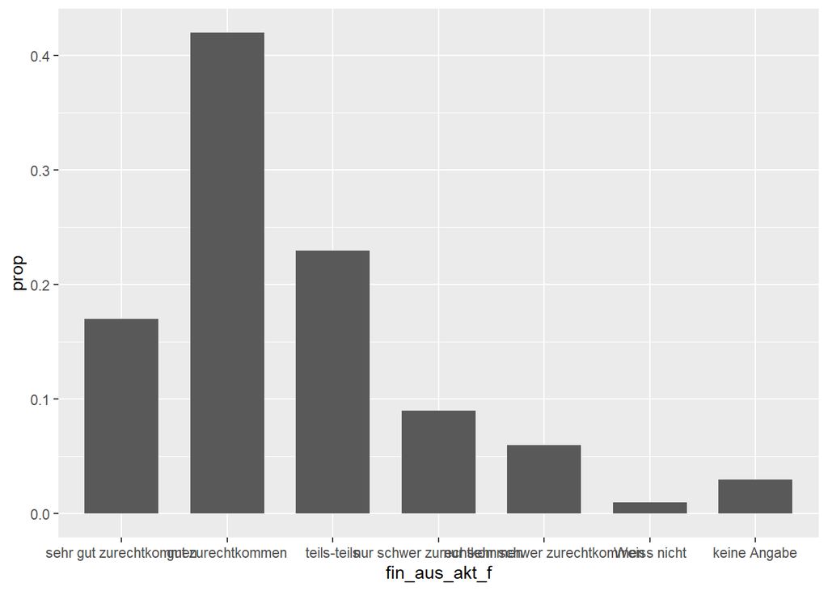

```r
#Export this table in .csv format
write.csv(data_sum %>% select(fin_aus_akt_f,prop,ymax,ymin,N), "./output/tables/summarytable_fin.csv", na = "NA")

####
# Bar Graph
# Basic ggplot code

ggplot(data_sum, aes(x=fin_aus_akt_f, y=prop)) +  # what dataset should ggplot use + what variables should be plotted where
    geom_bar(position="identity", stat = "identity", width=0.7) # what "geom" etric shape should ggplot use + where should these be plotted ("identity" in this case = at the exact position of x + with the exact height of y, width = how wide should the bars be visually)
```

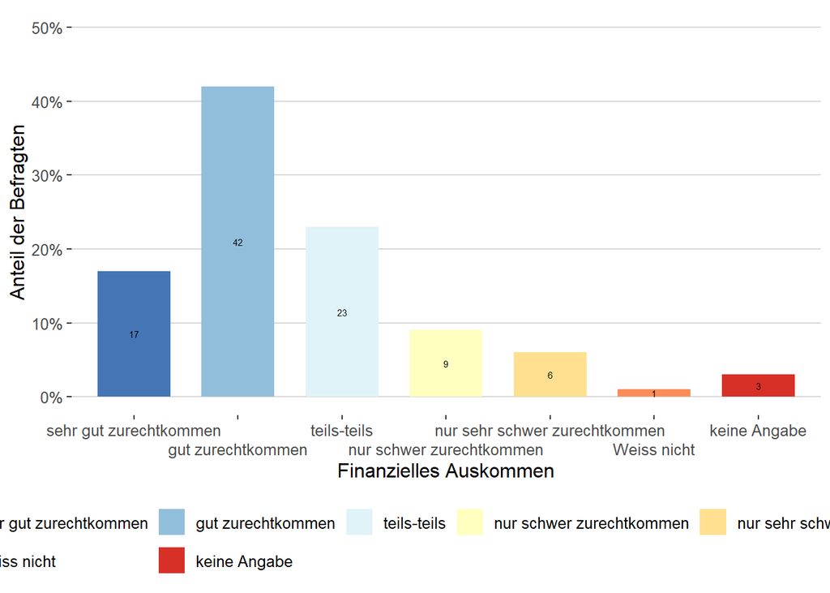

```r
#make it more readable and more visually pleasing
ggplot(data_sum, aes(fill=fin_aus_akt_f,x=fin_aus_akt_f, y=prop)) + # change also the fill color according to a variable
    geom_bar(position="identity", show.legend = TRUE,stat = "identity", width=0.7) + # show a legend for the fill color
    geom_text(aes(label=round(prop*100, digits = 1)), position=position_stack(vjust=0.5), color="black", size=2) + # print also the value of the bars in a text form positioned at the middle of the bars
    scale_fill_brewer(palette = "RdYlBu", direction=-1) +  # color the bars from rd over yellow to blue in the opposite direction
    labs(y = "Anteil der Befragten", x= "Finanzielles Auskommen",fill="") + # rename the axis labels and delete the legend title
    scale_y_continuous(labels = scales::percent_format(accuracy = 1),limits = c(0,.5),breaks = seq(0, .5, by = .1)) + # rescale the y axis so that it displays % and only goes from 0 to .5 (50%) make horicontal grid lines and label them in the axis every .1 (10%)
    theme_hc() + # use a ggplot theme where only horicontal grid lines are plotted (other options "minimal", "classic" etc)
    theme(legend.position="bottom") + # position the legend at the bottom of the graph
    guides(fill=guide_legend(ncol=5,nrow=2,byrow=TRUE)) +  #use 5 collums and 2 rows to display the items in the legend
    scale_x_discrete(guide = guide_axis(n.dodge = 2)) # vary the y position of the x axis labels to make them more readable
```

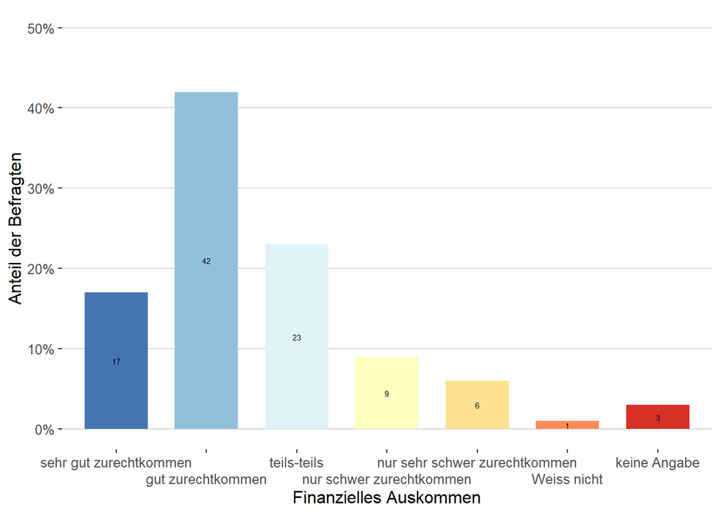

```r
# the legend contains redundant information so let's not display it
ggplot(data_sum, aes(fill=fin_aus_akt_f,x=fin_aus_akt_f, y=prop)) +
    geom_bar(position="identity", show.legend = FALSE,stat = "identity", width=0.7) + # Here legend False instead of True
    geom_text(aes(label=round(prop*100, digits = 1)), position=position_stack(vjust=0.5), color="black", size=2) +
    scale_fill_brewer(palette = "RdYlBu", direction=-1) +
    labs(y = "Anteil der Befragten", x= "Finanzielles Auskommen",fill="") +
    scale_y_continuous(labels = scales::percent_format(accuracy = 1),limits = c(0,.5),breaks = seq(0, .5, by = .1)) +
    theme_hc() +
    theme(legend.position="bottom") +
    guides(fill=guide_legend(ncol=5,nrow=2,byrow=TRUE)) +
    scale_x_discrete(guide = guide_axis(n.dodge = 2))
```

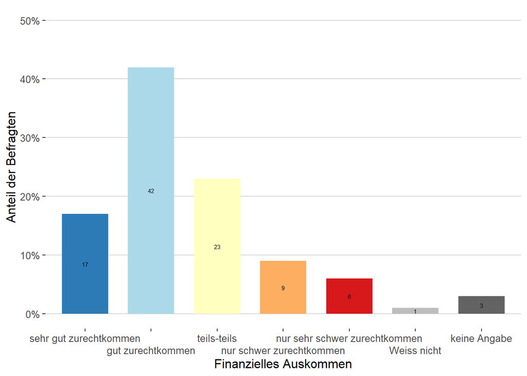

```r
# the colouring is somewhat confusing so let's make a clear distinction between substantial answers and missing values
newfillp5<-c(brewer.pal(5, name="RdYlBu")[5:1],brewer.pal(3, name="Greys")[c(2,3)]) # generate new color palette

ggplot(data_sum, aes(fill=fin_aus_akt_f,x=fin_aus_akt_f, y=prop)) +
    geom_bar(position="identity", show.legend = FALSE,stat = "identity", width=0.7) +
    geom_text(aes(label=round(prop*100, digits = 1)), position=position_stack(vjust=0.5), color="black", size=2) +
    scale_fill_manual(values=newfillp5) + # manually color the fill of the bars
    labs(y = "Anteil der Befragten", x= "Finanzielles Auskommen",fill="") +
    scale_y_continuous(labels = scales::percent_format(accuracy = 1),limits = c(0,.5),breaks = seq(0, .5, by = .1)) +
    theme_hc() +
    theme(legend.position="bottom") +
    guides(fill=guide_legend(ncol=5,nrow=2,byrow=TRUE)) +
    scale_x_discrete(guide = guide_axis(n.dodge = 2))
```

```r
ggsave("Figure1.png", units="in", width=7, height=4, type="cairo-png") # save the graph as png file using this size in inches, flatten the edges using cairo. Note that you have to run this line at the same time you are running the ggplot code

#ggsave("./output/figures/Figure1.png", units="in", width=7, height=4) # if cairo does not work on your PC use this
```

## Descriptive overview of our main target relationship

We are not only interested in the answer share of our dependent variable but how these answers relate to our independent variables of interest. The following code calculates the weighted average financial satisfaction dependent on the labor market status of the individuals. We export these results in form of a table and of a scatterplot with confidence intervals of the means. These results provide us with a first descriptive overview about the relationship between these two variables (financial satisfaction and labor market status) in the data.

```r
data_sum_N<-dataset_r_rec %>% filter(!is.na(fin_aus_akt_n) & !is.na(lab_sta_cur)) %>%  # only use individuals with not NA both of our individuals of interest
 ungroup() %>% tally()

data_sum_N
```

```
## # A tibble: 1 x 1
##       n
##   <int>
## 1  1490
```

```r
data_mean <- dataset_r_rec  %>% filter(!is.na(fin_aus_akt_n) & !is.na(lab_sta_cur)) %>%
  as_survey_design(weights = c(W6_WEIGHTD)) %>%
  group_by(lab_sta_cur) %>% # group the data by the levels in the variable lab_sta_cur
  summarise(mean=survey_mean(fin_aus_akt_n,vartype = c("se"))) %>% # calculate the weighted mean
  group_by(lab_sta_cur) %>%
     mutate(ymax=mean+1.96*mean_se, ymin=mean-1.96*mean_se) # calculate the aprox. upper and lower tail of the 95% confidence interval

data_mean <- data_mean %>% mutate(mean=round(mean,2), #round the values
                                ymax=round(ymax,3),
                                ymin=round(ymin,3),
                                N=data_sum_N$n)

data_mean %>% select(lab_sta_cur,mean,ymax,ymin,N)
```

```
## # A tibble: 7 x 5
## # Groups:   lab_sta_cur [7]
##   lab_sta_cur                       mean  ymax  ymin     N
##   <fct>                            <dbl> <dbl> <dbl> <int>
## 1 (Un)selbststaendig erwerbstaetig  2.56  2.69  2.44  1490
## 2 in Kurzarbeit                     2.42  2.57  2.27  1490
## 3 in Home Office                    2.95  3.06  2.83  1490
## 4 Arbeitslos                        1.66  1.91  1.41  1490
## 5 in Pension                        2.78  2.89  2.67  1490
## 6 in Ausbildung                     2.76  2.98  2.54  1490
## 7 Sonstige                          2.39  2.67  2.10  1490
```

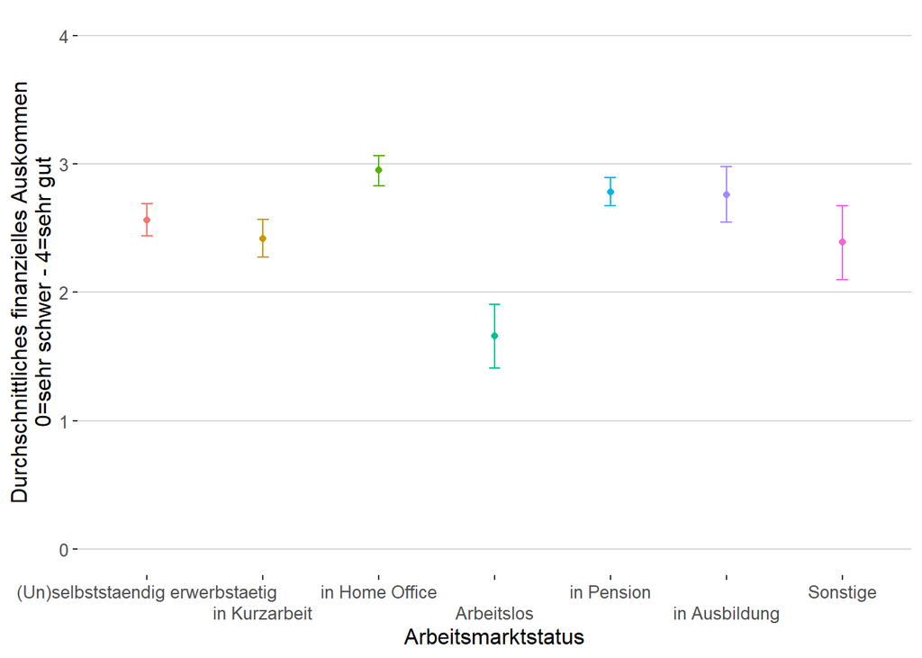

```r
#Export this table in .csv format
write.csv(data_mean %>% select(lab_sta_cur,mean,ymax,ymin,N), "./output/tables/meantable_fin.csv", na = "NA")

#display the means in form of a scatterplot

ggplot(data_mean, aes(color=lab_sta_cur,x=lab_sta_cur, y=mean)) + #color instead of fill because points have colors and no fill
    geom_point(position="identity", show.legend = FALSE,stat = "identity") + #geom_point instead of geom_bar
    geom_errorbar(aes(ymin=ymin,ymax=ymax),width=.1, show.legend = FALSE) + # add sescond geometric shape in form of errorbars in addition to the points indicating the means
    labs(y = "Durchschnittliches finanzielles Auskommen\n0=sehr schwer - 4=sehr gut", x= "Arbeitsmarktstatus",color="") +
    scale_y_continuous(limits = c(0,4),breaks = seq(0, 4, by = 1)) +
    theme_hc() +
    scale_x_discrete(guide = guide_axis(n.dodge = 2))
```

## Statistical models to test our hypotheses (OLS Regressions)

Finally, we can move to actually testing our hypotheses using the very minimal identification strategy of a cross-sectional data analysis, where we assume that we control for all potential selection/confounders of our variables of interest. First we test H1, then H2. Our estimatgion strategy uses a linear regression with an ordinary least squares estimator (OLS). We export the results in form of a regression table, a coefficient plot and a plot indicating Average marginal effects.

```r
#Let us start with a very basic linear regression

mymodel1<-lm(fin_aus_akt_n~lab_sta_cur,data=dataset_r_rec,weights=W6_WEIGHTD)

# the lm function works in the following form: lm(DV~IV1+IV2...+IVN, data=dataset,weights=weights) where DV is the dependent variable of interest and IV1-N are n potential indipendent variables.

#We can look at the results using the summary function:
summary(mymodel1)
```

```
##
## Call:
## lm(formula = fin_aus_akt_n ~ lab_sta_cur, data = dataset_r_rec,
##     weights = W6_WEIGHTD)
##
## Weighted Residuals:
##     Min      1Q  Median      3Q     Max
## -4.3084 -0.5505  0.2022  0.5594  3.3194
##
## Coefficients:
##                           Estimate Std. Error t value Pr(>|t|)
## (Intercept)                2.56343    0.05195  49.340  < 2e-16 ***
## lab_sta_curin Kurzarbeit  -0.14219    0.08960  -1.587  0.11276
## lab_sta_curin Home Office  0.38411    0.08887   4.322 1.65e-05 ***
## lab_sta_curArbeitslos     -0.90502    0.10299  -8.788  < 2e-16 ***
## lab_sta_curin Pension      0.21870    0.07257   3.014  0.00263 **
## lab_sta_curin Ausbildung   0.19682    0.11154   1.764  0.07786 .
## lab_sta_curSonstige       -0.17754    0.11564  -1.535  0.12494
## ---
## Signif. codes:  0 '***' 0.001 '**' 0.01 '*' 0.05 '.' 0.1 ' ' 1
##
## Residual standard error: 1.008 on 1483 degrees of freedom
##   (61 observations deleted due to missingness)
## Multiple R-squared:  0.09794,    Adjusted R-squared:  0.09429
## F-statistic: 26.83 on 6 and 1483 DF,  p-value: < 2.2e-16
```

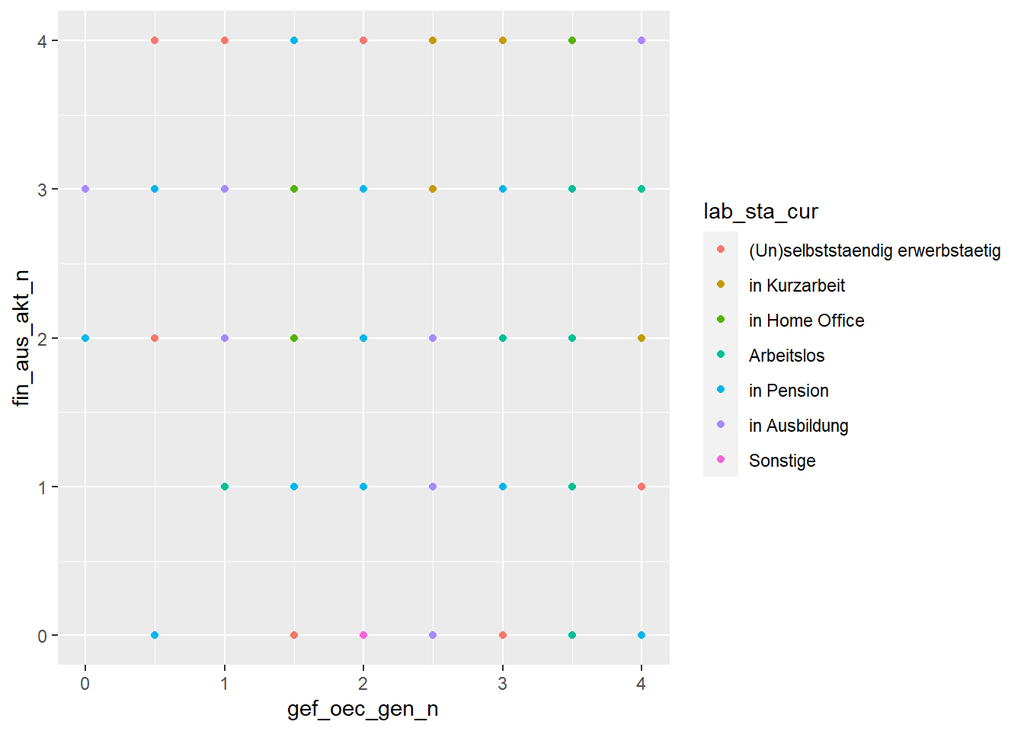

```r
#We can see that for example individuals who are "Arbeitslos" have -0.90 (=.90 less) financial satisfaction compared to our reference group which is automatically the group with the lowest factor level (in our case "(Un)selbststaendig erwerbstaetig"). This seems quite logica l and relates to the descriptive results we received in the previous section. In fact if we calculate the differences in the means between the those "Arbeitslos" and "(Un)selbststaendig erwerbstaetig" we would receive the same value of 0.90.

#For those in  Kurzarbeit we also find lower financial satisfaction compared to the reference group (-0.14219) but this difference is not statistically significantly different from 0 assuming a significance level of p<0.05. Quite contrary to what could expect those in Home Office actually are statistically significant more satisfied with their financial sitation compared to the reference group (0.38411, p<.001). Why would you think this is the case?

#We also hypothesized that those who think the Covid-19 pandemic poses a great economic threat would be less satisfied with their income than those who think that the COVID-19 pandemic poses less of a threat.

# We can cisualize this relationship again
ggplot(dataset_r_rec%>%filter(!is.na(lab_sta_cur)), aes(color=lab_sta_cur,x=gef_oec_gen_n, y=fin_aus_akt_n)) +
  geom_point()
```

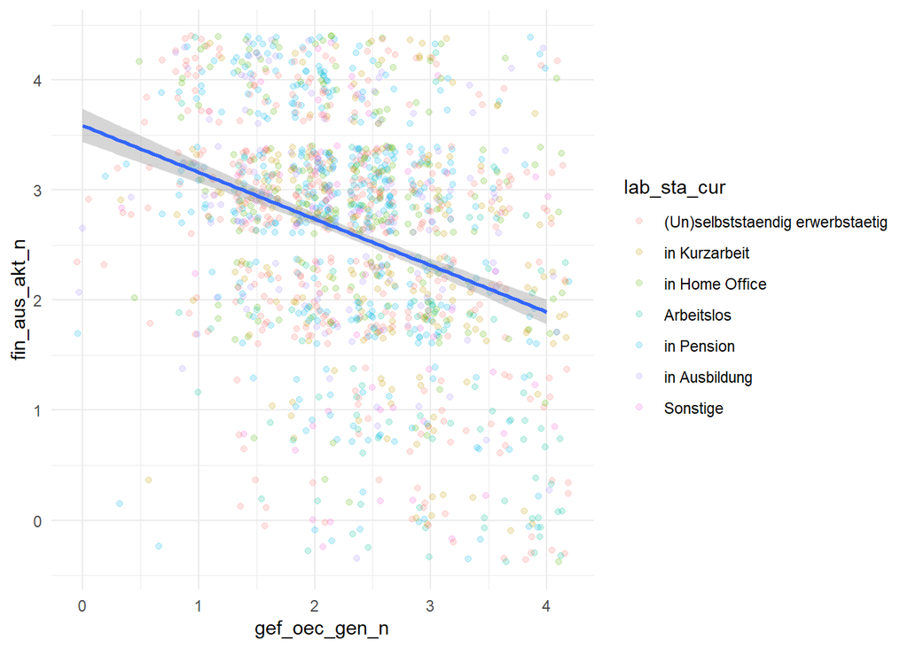

```r
#Because we have only a small number of potential oucomes (answers of our question) the points overlap quite substantially we can avoid that by jittering the points a little bit and making them party transparent. Afterwards we calculate a trend line.

ggplot(dataset_r_rec%>%filter(!is.na(lab_sta_cur)), aes(x=gef_oec_gen_n, y=fin_aus_akt_n)) +
  geom_jitter(aes(color=lab_sta_cur),alpha=.2) +
  geom_smooth(method=lm,se = TRUE) +
  theme_minimal()
```

```r
#Now let's add this variable as an independent variable to our model.

mymodel2<-lm(fin_aus_akt_n~lab_sta_cur + gef_oec_gen_n,data=dataset_r_rec,weights=W6_WEIGHTD)

#How would you interpret the result?
summary(mymodel2)
```

```
##
## Call:
## lm(formula = fin_aus_akt_n ~ lab_sta_cur + gef_oec_gen_n, data = dataset_r_rec,
##     weights = W6_WEIGHTD)
##
## Weighted Residuals:
##     Min      1Q  Median      3Q     Max
## -4.5921 -0.5242  0.1179  0.5725  2.8588
##
## Coefficients:
##                           Estimate Std. Error t value Pr(>|t|)
## (Intercept)                3.41181    0.08460  40.331  < 2e-16 ***
## lab_sta_curin Kurzarbeit  -0.03962    0.08589  -0.461  0.64464
## lab_sta_curin Home Office  0.36504    0.08432   4.329 1.60e-05 ***
## lab_sta_curArbeitslos     -0.69396    0.09960  -6.968 4.84e-12 ***
## lab_sta_curin Pension      0.20134    0.06894   2.920  0.00355 **
## lab_sta_curin Ausbildung   0.14312    0.10596   1.351  0.17701
## lab_sta_curSonstige       -0.18121    0.11014  -1.645  0.10011
## gef_oec_gen_n             -0.36659    0.03020 -12.140  < 2e-16 ***
## ---
## Signif. codes:  0 '***' 0.001 '**' 0.01 '*' 0.05 '.' 0.1 ' ' 1
##
## Residual standard error: 0.9544 on 1474 degrees of freedom
##   (69 observations deleted due to missingness)
## Multiple R-squared:  0.1776, Adjusted R-squared:  0.1736
## F-statistic: 45.46 on 7 and 1474 DF,  p-value: < 2.2e-16
```